# Homework Assignment #2: Regression Assumptions, Analytic Strategies, Polynominal Regression, & Interactions Among Continuous Variables

EDUC/PSY 7610: Regression Analysis

Instructor: Jamison Fargo, PhD

March 13, 2023

Please complete the following exercises. You must include the code (as brief as possible) that was used to run each exercise along with the results. You may work in groups of 2 or 3 if you like, but each student should submit their own homework assignment. You will be able to upload your completed assignment to CANVAS. You may complete these exercises using BlueSky or R Studio (eg, script or R Markdown).

### Part I: Regression Assumptions

What regression assumptions can you test with each of the following displays?

1. Histogram or Q-Q plot of residuals.

**Answer:**

Histogram and Q-Q plots of residuals are useful tools for assessing the normality, homoscedasticity, and linearity assumptions of linear regression.

1.Normality assumption: If the residuals are normally distributed, the histogram will resemble a bell-shaped curve and the Q-Q plot will be a straight line. Otherwise, the histogram will have an unusual shape, and the Q-Q plot will be curved.

2.Homoscedasticity assumption: If the residuals are homoscedastic, the histogram will show a roughly equal distribution of residuals above and below zero, and the Q-Q plot will have a roughly straight line. If the residuals are heteroscedastic, the histogram will show a skewed distribution of residuals, and the Q-Q plot will have a curved line.

3.Linearity assumption: If the relationship between the dependent variable and each independent variable is linear, the histogram and Q-Q plot of residuals will not show any discernible pattern.

2. Plot of residuals against predicted values.

**Answer:**

The plot of residuals against predicted values (residuals vs. fitted) can be used to test the assumptions of linearity, homoscedasticity, and independence of a linear regression model.

1.Linearity: If the plot shows a random scatter of residuals around zero, it suggests that the linear assumption is valid. However, if there is a pattern or curvature in the plot, it indicates that the relationship between the variables is not linear.

2.Homoscedasticity: A random scatter of residuals around zero suggests that the homoscedasticity assumption is valid. However, if the residuals are not randomly scattered and show a cone shape, it indicates that the variability of the residuals is not constant, and there may be a violation of the homoscedasticity assumption.

3.Independence: If there is no pattern or correlation between the residuals in the plot, it suggests that the independence assumption is valid. However, if the plot shows a pattern or correlation between the residuals, it indicates that the residuals are not independent.

3. Plot of residuals against each predictor.

**Answer:**

The plot of residuals against each predictor can be used to evaluate the linearity, independence, and homoscedasticity of the residuals, as well as to detect outliers and influential observations.

1.Linearity: If the points on the plot form a roughly straight line, this suggests that the relationship is linear.

2.Independence: If there is a clear pattern or trend in the residuals as the predictor variable changes, this suggests that the residuals are not independent and may violate the assumption of independence.

3.Homoscedasticity: If the residuals are homoscedastic, the points on the plot should be evenly scattered around a horizontal line, with no clear pattern of increasing or decreasing variability as the predictor variable changes.

4.Outliers and influential observations: Outliers are observations that are far away from the other observations and can have a large impact on the regression results. Influential observations are observations that have a large influence on the regression results, even if they are not outliers. These observations can be identified as points that are far away from the other points on the plot.

4. Partial regression (or CERES) plots.

**Answer:**

Partial regression (or CERES) plots are a type of diagnostic plot that can be used to assess the assumptions of linear regression models. Specifically, they can be used to evaluate whether the relationship between the response variable and a particular predictor variable is linear, whether the residuals are normally distributed, and whether there is homoscedasticity of the residuals.

1.Linearity: The partial regression plot can be used to assess whether the relationship between the response variable and the predictor variable is linear. If the points on the plot form a straight line, this suggests that the relationship is linear.

2.Normality: The partial regression plot can also be used to assess whether the residuals are normally distributed. If the residuals are normally distributed, the points on the plot should be randomly scattered around the horizontal line at zero.

3.Homoscedasticity: The partial regression plot can be used to check for homoscedasticity of the residuals. If the residuals are homoscedastic, the points on the plot should be evenly scattered around the horizontal line at zero, with no clear pattern of increasing or decreasing variability as the predictor variable changes.

### Part II: Checking Assumptions & Transforming Data I

Complete the following exercises using the `GSS.xlsx` data set.

1. Conduct a multiple linear regression analysis of participant education (`educ`) on primary caregiver’s education (`paeduc`), partner’s education (`prtneduc`), hours of television watched per day (`tvhours`), and income in dollars (`rincmdol`).

```r
library(tidyverse)
library(car)
```

```r
library(carData)
library(ggpubr)
library(jtools)
library(broom)
library(cowplot)
library(lmtest)
library(gtsummary)
library(apaTables)
library(ppcor)
library(readxl)
library(dplyr)
gss<- read_excel("C:\\Users\\Rifatul Islam Himel\\Downloads\\GSS.xlsx")
head(gss)
```

```
## # A tibble: 6 × 50
##     AGE SEX     EDUC INCOME91   WRKSTAT RICHW…¹ SATJOB LIFE  IMPJOB  HRS1 DEGREE
##   <dbl> <chr>  <dbl> <chr>      <chr>   <chr>   <chr>  <chr> <chr>  <dbl> <chr>
## 1    43 Male      11 $40000-49… Workin… Contin… Mod s… Rout… Very …    35 High …
## 2    44 Male      16 $40000-49… Workin… Contin… Very … Exci… Very …    21 Bache…
## 3    43 Female    16 $40000-49… Workin… Contin… Very … Exci… One o…    45 Bache…
## 4    45 Female    15 REFUSED    Workin… Not ap… A lit… Not … Very …    20 High …
## 5    78 Female    17 $75000+    Retired Not ap… Not a… Exci… Very …    -1 Gradu…
## 6    83 Male      11 $20000-22… Retired Not ap… Not a… Rout… One o…    -1 High …
## # … with 39 more variables: ANOMIA5 <chr>, DEGREE2 <chr>, MAEDUC <dbl>,
## #   PAEDUC <dbl>, MACOLLEG <chr>, PACOLLEG <chr>, SATJOB2 <chr>, MARITAL <chr>,
## #   AGEWED <dbl>, SPWRKSTA <chr>, SPHRS1 <dbl>, SIBS <dbl>, ZODIAC <chr>,
## #   PRTNEDUC <dbl>, SPDEG <chr>, PARTYID <chr>, VOTE92 <chr>, PRES92 <chr>,
## #   POSTLIFE <chr>, HAPPY <chr>, HAPMAR <chr>, JOBINC <chr>, CLASSICL <chr>,
## #   OPERA <chr>, COUNTRY <chr>, RINCOM91 <chr>, TVHOURS <dbl>, FINRELA <chr>,
## #   WIFEDUC <chr>, HUSBEDUC <chr>, INCOMDOL <chr>, RINCMDOL <dbl>, ID <dbl>, …
```

```r
names(gss)
```

```
##  [1] "AGE"      "SEX"      "EDUC"     "INCOME91" "WRKSTAT"  "RICHWORK"
##  [7] "SATJOB"   "LIFE"     "IMPJOB"   "HRS1"     "DEGREE"   "ANOMIA5"
## [13] "DEGREE2"  "MAEDUC"   "PAEDUC"   "MACOLLEG" "PACOLLEG" "SATJOB2"
## [19] "MARITAL"  "AGEWED"   "SPWRKSTA" "SPHRS1"   "SIBS"     "ZODIAC"
## [25] "PRTNEDUC" "SPDEG"    "PARTYID"  "VOTE92"   "PRES92"   "POSTLIFE"
## [31] "HAPPY"    "HAPMAR"   "JOBINC"   "CLASSICL" "OPERA"    "COUNTRY"
## [37] "RINCOM91" "TVHOURS"  "FINRELA"  "WIFEDUC"  "HUSBEDUC" "INCOMDOL"
## [43] "RINCMDOL" "ID"       "HUSBHR"   "WIFEHR"   "HUSBFT"   "WIFEFT"
## [49] "EDUCDIFF" "INCOME4"
```

```r
gss.lm.1 <- lm(EDUC ~ PAEDUC + PRTNEDUC + TVHOURS + RINCMDOL, data = gss)
summ(gss.lm.1)
```

```
## MODEL INFO:
## Observations: 442 (1058 missing obs. deleted)
## Dependent Variable: EDUC
## Type: OLS linear regression
##
## MODEL FIT:
## F(4,437) = 102.35, p = 0.00
## R² = 0.48
## Adj. R² = 0.48
##
## Standard errors: OLS
## ------------------------------------------------
##                      Est.   S.E.   t val.      p
## ----------------- ------- ------ -------- ------
## (Intercept)          6.13   0.56    10.92   0.00
## PAEDUC               0.12   0.03     4.72   0.00
## PRTNEDUC             0.44   0.04    10.88   0.00
## TVHOURS             -0.19   0.06    -3.06   0.00
## RINCMDOL             0.00   0.00     7.15   0.00
## ------------------------------------------------
```

2. Write out the results of the initial regression analysis as an equation for 1) observed and 2) predicted values of the outcome variable (`educ`).

```r
b0 <- coef(gss.lm.1)[1]
b1 <- coef(gss.lm.1)[2]
b2 <- coef(gss.lm.1)[3]
b3 <- coef(gss.lm.1)[4]
b4 <- coef(gss.lm.1)[5]

observed_eqn <- paste("Observed Equation:"," ", "EDUC = ", round(b0, 2), " + ", round(b1, 2), "* PAEDUC" , " + ", round(b2, 2), "* PRTNEDU", " - ",round(-b3, 2), "* TVHOURS" , " + ",round(b4, 2), "* RINCMDOL + e", sep = "")

observed_eqn
```

```
## [1] "Observed Equation: EDUC = 6.13 + 0.12* PAEDUC + 0.44* PRTNEDU - 0.19* TVHOURS + 0* RINCMDOL + e"
```

```r
predicted_eqn <- paste("Predicted Equation:"," ","EDUC = ", round(b0, 2), " + ", round(b1, 2), "* PAEDUC" , " + ", round(b2, 2), "* PRTNEDU", " - ",round(-b3, 2), "* TVHOURS" , " + ",round(b4, 2), "* RINCMDOL", sep = "")

predicted_eqn
```

```
## [1] "Predicted Equation: EDUC = 6.13 + 0.12* PAEDUC + 0.44* PRTNEDU - 0.19* TVHOURS + 0* RINCMDOL"
```

3. How does a 1-unit increase in TV watching affect participant education?

**Answer:** Participant education had a negative relationship with TV watching in that for every 1-unit increase in TV watching, Participant education decreased by 0.19-unit (p < .01).

4. What is the result of the omnibus test for the fit of the regression model (ie, *F*-test)?

```r
summary(gss.lm.1)
```

```
##
## Call:
## lm(formula = EDUC ~ PAEDUC + PRTNEDUC + TVHOURS + RINCMDOL, data = gss)
##
## Residuals:
##      Min       1Q   Median       3Q      Max
## -10.1912  -1.1609   0.0111   1.1651   7.6752
##
## Coefficients:
##               Estimate Std. Error t value Pr(>|t|)
## (Intercept)  6.131e+00  5.615e-01  10.920  < 2e-16 ***
## PAEDUC       1.239e-01  2.622e-02   4.724 3.12e-06 ***
## PRTNEDUC     4.385e-01  4.031e-02  10.878  < 2e-16 ***
## TVHOURS     -1.909e-01  6.232e-02  -3.064  0.00232 **
## RINCMDOL     3.225e-05  4.511e-06   7.150 3.67e-12 ***
## ---
## Signif. codes:  0 '***' 0.001 '**' 0.01 '*' 0.05 '.' 0.1 ' ' 1
##
## Residual standard error: 2.058 on 437 degrees of freedom
##   (1058 observations deleted due to missingness)
## Multiple R-squared:  0.4837, Adjusted R-squared:  0.479
## F-statistic: 102.3 on 4 and 437 DF,  p-value: < 2.2e-16
```

F-statistic: This is the value of the F-test statistic, which measures the ratio of the explained variance to the unexplained variance in the model. It indicates how well the model fits the data, with larger values indicating a better fit. In this case, the F-statistic is 102.3, which suggests a good fit of the model to the data.

DF: These values represent the degrees of freedom associated with the F-statistic. The first value (4) is the degrees of freedom associated with the numerator, which is the number of predictor variables in the model. The second value (437) is the degrees of freedom associated with the denominator, which is the residual degrees of freedom.

p-value: This is the probability of obtaining an F-statistic as large as the observed one, assuming that the null hypothesis (i.e., that all the coefficients in the model are zero) is true. A small p-value indicates strong evidence against the null hypothesis, suggesting that at least one of the coefficients in the model is significantly different from zero. In this case, the p-value is very small (less than 2.2e-16), indicating strong evidence against the null hypothesis and in favor of the alternative hypothesis (i.e., that at least one of the coefficients in the model is different from zero).

5. What is the interpretation of $R^2$?

**Answer:**

$R^2$ of this model is 0.48. This means that the four independent variables (primary caregiver’s education, partner’s education, hours of television watched per day, and income in dollars) in the model explain 48% of the variation in the dependent variable or Participant education.

6. By including the variable `prtneduc` in the analysis, what is the effect on the generalizability of the results?

```r
gss.lm.2 <- lm(EDUC ~ PAEDUC + TVHOURS + RINCMDOL, data = gss)
summ(gss.lm.2)
```

```
## MODEL INFO:
## Observations: 753 (747 missing obs. deleted)
## Dependent Variable: EDUC
## Type: OLS linear regression
##
## MODEL FIT:
## F(3,749) = 103.43, p = 0.00
## R² = 0.29
## Adj. R² = 0.29
##
## Standard errors: OLS
## ------------------------------------------------
##                      Est.   S.E.   t val.      p
## ----------------- ------- ------ -------- ------
## (Intercept)         10.77   0.30    35.47   0.00
## PAEDUC               0.23   0.02    10.84   0.00
## TVHOURS             -0.24   0.05    -5.14   0.00
## RINCMDOL             0.00   0.00     9.88   0.00
## ------------------------------------------------
```

```r
summary(gss.lm.2)$adj.r.squared
```

```
## [1] 0.2900975
```

```r
summary(gss.lm.1)$adj.r.squared
```

```
## [1] 0.4789584
```

```r
summary(gss.lm.1)$r.squared - summary(gss.lm.2)$r.squared #contribution of the variable 'PRTNEDUC' in the analysis
```

```
## [1] 0.1907548
```

By including the variable `prtneduc` in the analysis, the contribution of the variable `prtneduc` in the analysis = 0.1907548

7. Using the standardized deleted residuals and predicted (ie, fitted) values, apply the methods for regression diagnostics as discussed in class to check the assumptions of independence, normality, homogeneity of variance, and linearity.  
   7.1. Present both a figure as well as the results of a statistical technique for checking each assumption. When testing for linearity, create CERES plots for visual evaluation of this assumption.  
   **Independence Assumption:**

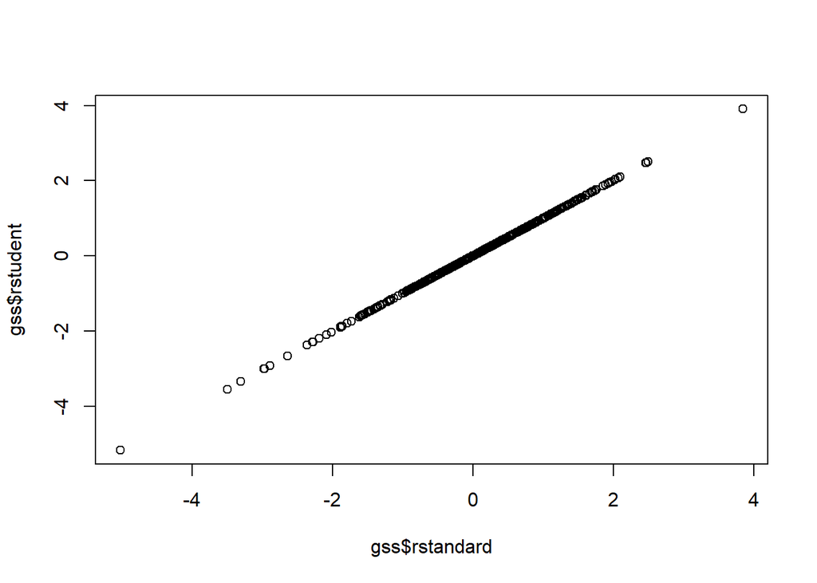

```r
gss <- gss %>%
  drop_na()

gss$predicted <- fitted(gss.lm.1)
gss$residuals <- residuals(gss.lm.1)
gss$rstudent <- rstudent(gss.lm.1)
gss$rstandard <- rstandard(gss.lm.1)
plot(gss$rstandard, gss$rstudent)
```

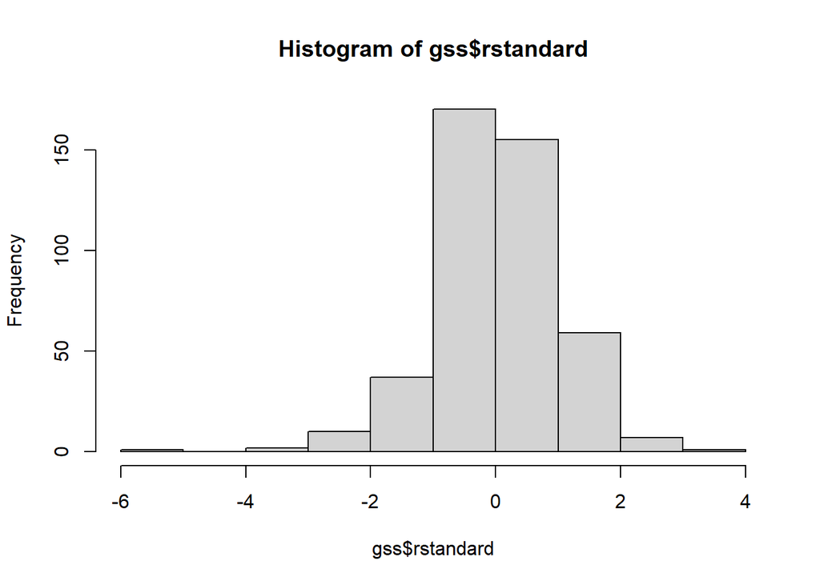

```r
hist(gss$rstandard)
```

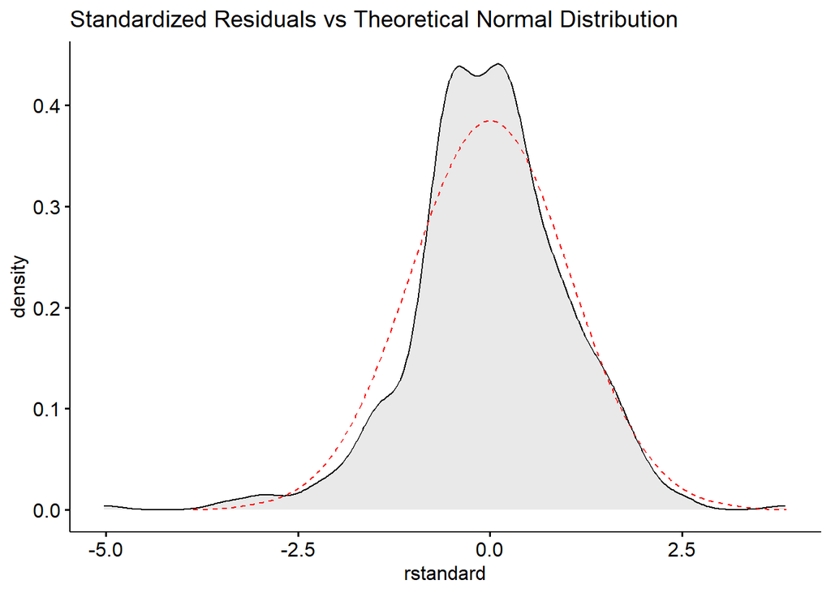

```r
ggdensity(gss,
          x = "rstandard",
          fill = "lightgray",
          title = "Standardized Residuals vs Theoretical Normal Distribution") +
  stat_overlay_normal_density(color = "red",
                              linetype = "dashed")
```

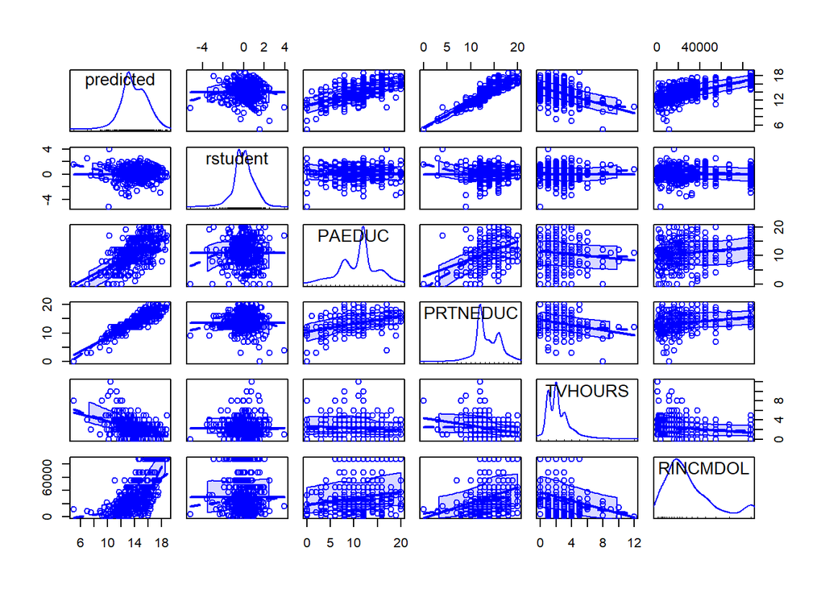

```r
scatterplotMatrix(~predicted + rstudent + PAEDUC + PRTNEDUC + TVHOURS + RINCMDOL, data=gss)
```

```r
durbinWatsonTest(gss.lm.1)
```

```
##  lag Autocorrelation D-W Statistic p-value
##    1      0.01934698      1.960802     0.7
##  Alternative hypothesis: rho != 0
```

**Linearity Assumption:**

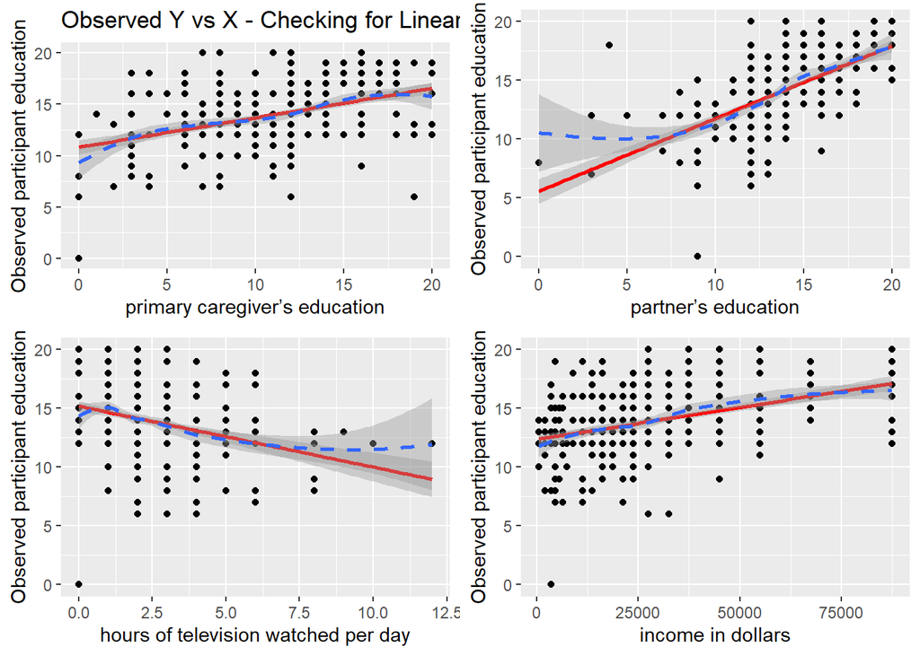

```r
#linearity visual assessment

#each X vs observed Y - look for smoothed vs linear trend difference
p1 <- ggplot(gss, aes(PAEDUC, EDUC)) +
  geom_point() +
  geom_smooth(method = lm, col = "red") +
  geom_smooth(method = loess, lty = 2) +
  ggtitle("Observed Y vs X - Checking for Linearity") +
  xlab("primary caregiver’s education") +
  ylab("Observed participant education")
p2 <- ggplot(gss, aes(PRTNEDUC, EDUC)) +
  geom_point() +
  geom_smooth(method = lm, col = "red") +
  geom_smooth(method = loess, lty = 2) +
  xlab("partner’s education") +
  ylab("Observed participant education")
p3 <- ggplot(gss, aes(TVHOURS, EDUC)) +
  geom_point() +
  geom_smooth(method = lm, col = "red") +
  geom_smooth(method = loess, lty = 2) +
  xlab("hours of television watched per day") +
  ylab("Observed participant education")
p4 <- ggplot(gss, aes(RINCMDOL, EDUC)) +
  geom_point() +
  geom_smooth(method = lm, col = "red") +
  geom_smooth(method = loess, lty = 2) +
  xlab("income in dollars") +
  ylab("Observed participant education")

plot_grid(p1, p2, p3, p4, ncol = 2, nrow = 2)
```

```r
#residuals vs each X
dev.off()
```

```r
gss.lm.1 <- lm(EDUC ~ PAEDUC + PRTNEDUC + TVHOURS + RINCMDOL, data = gss)
ceresPlots(gss.lm.1)
#residuals vs predicted Y - look for smoothed vs linear trend difference
plot(gss$rstandard ~ gss$predicted,
     main = "Standardized Residuals vs Predicted/Fitted Values",
     xlab = "Predicted/Fitted Values",
     ylab = "Standardized Residuals",
     cex = 1,
     col = "black")
abline(lm(gss$rstandard ~ gss$predicted),
       col = "red")
lines(lowess(gss$rstandard ~ gss$predicted),
      col = "blue", lty = 2)



#predicted vs observed Y - look for smoothed vs linear trend difference
plot(gss$predicted ~ gss$EDUC,
     main = "Predicted/Fitted vs Observed participant education",
     xlab = "Observed Values for participant education",
     ylab = "Predicted/Fitted Values for participant education",
     cex = 1,
     col = "black")
abline(lm(gss$predicted ~ gss$EDUC),
       col = "red")
lines(lowess(gss$predicted ~ gss$EDUC),
      col = "blue", lty = 2)


#linearity statistical assessment
resettest(gss.lm.1, power=2:3, type="regressor")
```

[output not shown]

```
##
##  RESET test
##
## data:  gss.lm.1
## RESET = 3.5928, df1 = 8, df2 = 429, p-value = 0.0004717
```

**Normality Assumption:**

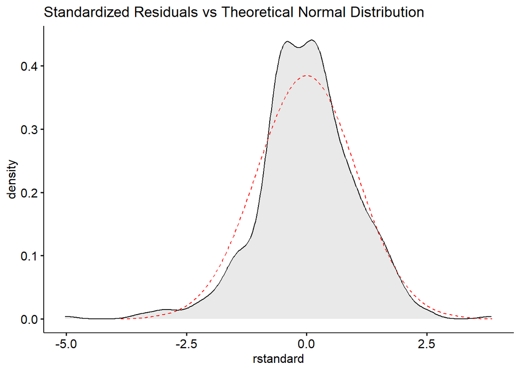

```r
ggdensity(gss,
          x = "rstandard",
          fill = "lightgray",
          title = "Standardized Residuals vs Theoretical Normal Distribution") +
  stat_overlay_normal_density(color = "red",
                              linetype = "dashed")
```

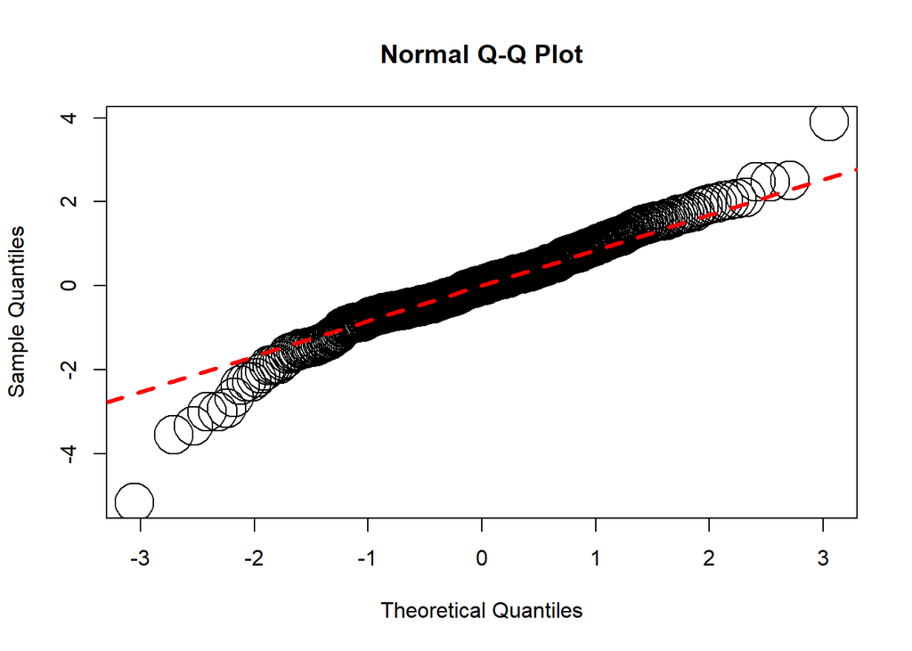

```r
qqnorm(rstudent(gss.lm.1), cex = 4)
qqline(rstudent(gss.lm.1), lty = 2, col = "red", lwd = 3)
```

```r
#normality statistical assessment
shapiro.test(gss$rstudent)
```

```
##
##  Shapiro-Wilk normality test
##
## data:  gss$rstudent
## W = 0.97531, p-value = 8.117e-07
```

**Homoscedasticity Assumption:**

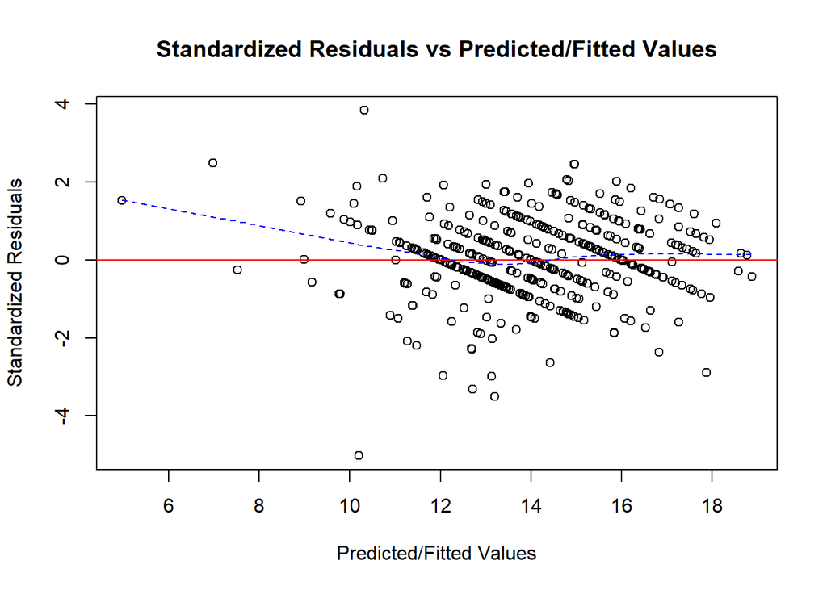

```r
plot(gss$rstandard ~ gss$predicted,
     main = "Standardized Residuals vs Predicted/Fitted Values",
     xlab = "Predicted/Fitted Values",
     ylab = "Standardized Residuals",
     cex = 1,
     col = "black")
abline(lm(gss$rstandard ~ gss$predicted),
       col = "red")
lines(lowess(gss$rstandard ~ gss$predicted),
      col = "blue", lty = 2)
```

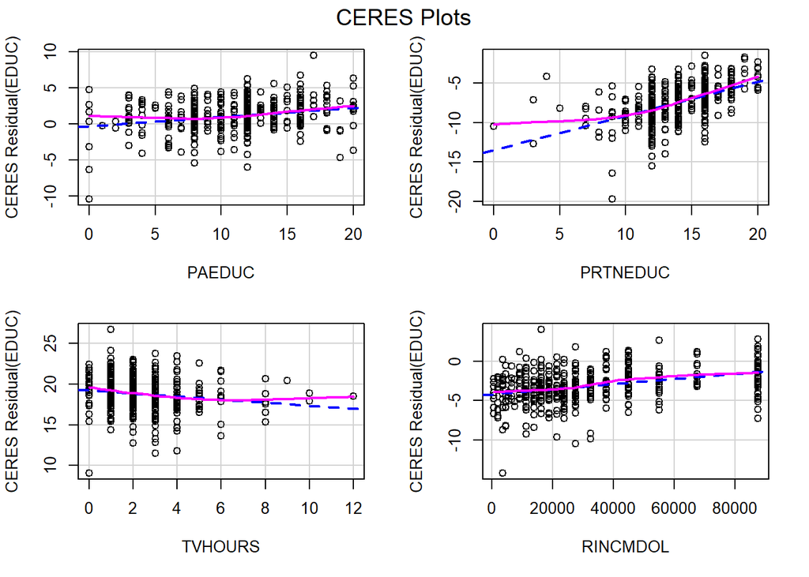

```r
#residuals vs each X
gss.lm.1 <- lm(EDUC ~ PAEDUC + PRTNEDUC + TVHOURS + RINCMDOL, data = gss)
ceresPlots(gss.lm.1)
```

```r
#homoscedasticity statistical assessment
bptest(gss.lm.1)
```

```
##
##  studentized Breusch-Pagan test
##
## data:  gss.lm.1
## BP = 13.355, df = 4, p-value = 0.009664
```

7.2. Report on whether the results of each procedure indicated a violation of regression assumptions.

**Independence Assumption:**

From the independence assumption graphs and Durbin Watson test, it can be concluded that there is no significant autocorrelation in the residuals of the regression analysis.D-W statistic is 1.960802, which is very close to the expected value of 2 under the null hypothesis of no autocorrelation.

**Linearity Assumption:**

From the linearity assumption graphs, CERES plot and RESET test, it can be concluded that there is a violation of linearity assumption. We need to compute a non-linear version (via a power transformation) of the predictor variable(s) and add it to the model.

**Normality Assumption:**

From the Normality assumption graphs and Shapiro-Wilk normality test, it can be concluded that normality assumption is violated. Since the p-value in this case is very small (8.117e-07), it suggests strong evidence against the null hypothesis.

**Homoscedasticity Assumption:**

From the homoscedasticity assumption graphs and studentized Breusch-Pagan test, it can be concluded that homoscedasticity assumption is violated. The p-value of BP test is less than 0.05 which represents the probability of observing a BP statistic as extreme as 13.355, assuming the null hypothesis is true. This also suggests that there is heteroscedasticity present in the data.

7.3. Apply the methods learned in class to try and correct any violations of assumptions, if necessary.  
7.4. Re-run the analysis with any transformed data.

**Both 7.3 and 7.4 are answered in the following segment**

```r
new_df<- subset(gss, select = c("EDUC", "PAEDUC", "PRTNEDUC", "TVHOURS", "RINCMDOL"))
summary(new_df)
```

```
##       EDUC           PAEDUC         PRTNEDUC        TVHOURS
##  Min.   : 0.00   Min.   : 0.00   Min.   : 0.00   Min.   : 0.000
##  1st Qu.:12.00   1st Qu.: 8.00   1st Qu.:12.00   1st Qu.: 1.000
##  Median :14.00   Median :12.00   Median :13.00   Median : 2.000
##  Mean   :13.99   Mean   :11.04   Mean   :13.62   Mean   : 2.321
##  3rd Qu.:16.00   3rd Qu.:13.00   3rd Qu.:16.00   3rd Qu.: 3.000
##  Max.   :20.00   Max.   :20.00   Max.   :20.00   Max.   :12.000
##     RINCMDOL
##  Min.   :  500
##  1st Qu.:13750
##  Median :23750
##  Mean   :29808
##  3rd Qu.:37500
##  Max.   :87500
```

```r
new_df$EDUC<- new_df$EDUC+1
new_df$PAEDUC<- new_df$PAEDUC+1
new_df$PRTNEDUC<- new_df$PRTNEDUC+1
new_df$TVHOURS <- new_df$TVHOURS+1

summary(new_df)
```

```
##       EDUC           PAEDUC         PRTNEDUC        TVHOURS
##  Min.   : 1.00   Min.   : 1.00   Min.   : 1.00   Min.   : 1.000
##  1st Qu.:13.00   1st Qu.: 9.00   1st Qu.:13.00   1st Qu.: 2.000
##  Median :15.00   Median :13.00   Median :14.00   Median : 3.000
##  Mean   :14.99   Mean   :12.04   Mean   :14.62   Mean   : 3.321
##  3rd Qu.:17.00   3rd Qu.:14.00   3rd Qu.:17.00   3rd Qu.: 4.000
##  Max.   :21.00   Max.   :21.00   Max.   :21.00   Max.   :13.000
##     RINCMDOL
##  Min.   :  500
##  1st Qu.:13750
##  Median :23750
##  Mean   :29808
##  3rd Qu.:37500
##  Max.   :87500
```

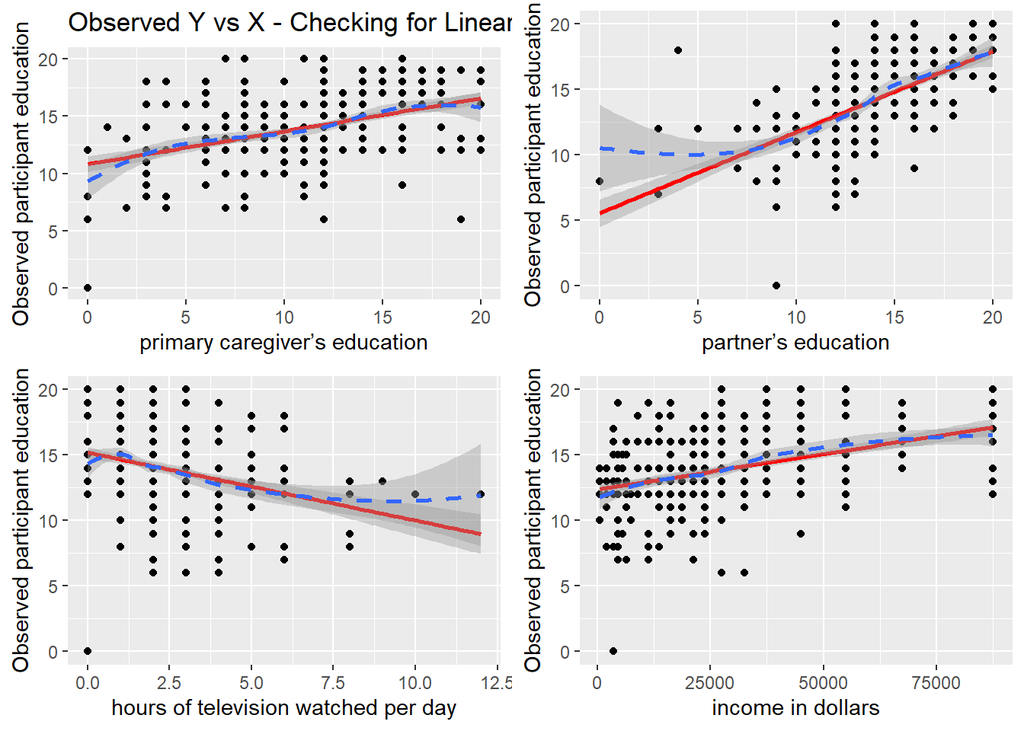

```r
plot_grid(p1, p2, p3, p4, ncol = 2, nrow = 2)
```

```r
gss.lm.1a <- lm(EDUC ~ PAEDUC + PRTNEDUC + TVHOURS + RINCMDOL, data = new_df)
summary(gss.lm.1a)
```

```
##
## Call:
## lm(formula = EDUC ~ PAEDUC + PRTNEDUC + TVHOURS + RINCMDOL, data = new_df)
##
## Residuals:
##      Min       1Q   Median       3Q      Max
## -10.1912  -1.1609   0.0111   1.1651   7.6752
##
## Coefficients:
##               Estimate Std. Error t value Pr(>|t|)
## (Intercept)  6.760e+00  6.282e-01  10.760  < 2e-16 ***
## PAEDUC       1.239e-01  2.622e-02   4.724 3.12e-06 ***
## PRTNEDUC     4.385e-01  4.031e-02  10.878  < 2e-16 ***
## TVHOURS     -1.909e-01  6.232e-02  -3.064  0.00232 **
## RINCMDOL     3.225e-05  4.511e-06   7.150 3.67e-12 ***
## ---
## Signif. codes:  0 '***' 0.001 '**' 0.01 '*' 0.05 '.' 0.1 ' ' 1
##
## Residual standard error: 2.058 on 437 degrees of freedom
## Multiple R-squared:  0.4837, Adjusted R-squared:  0.479
## F-statistic: 102.3 on 4 and 437 DF,  p-value: < 2.2e-16
```

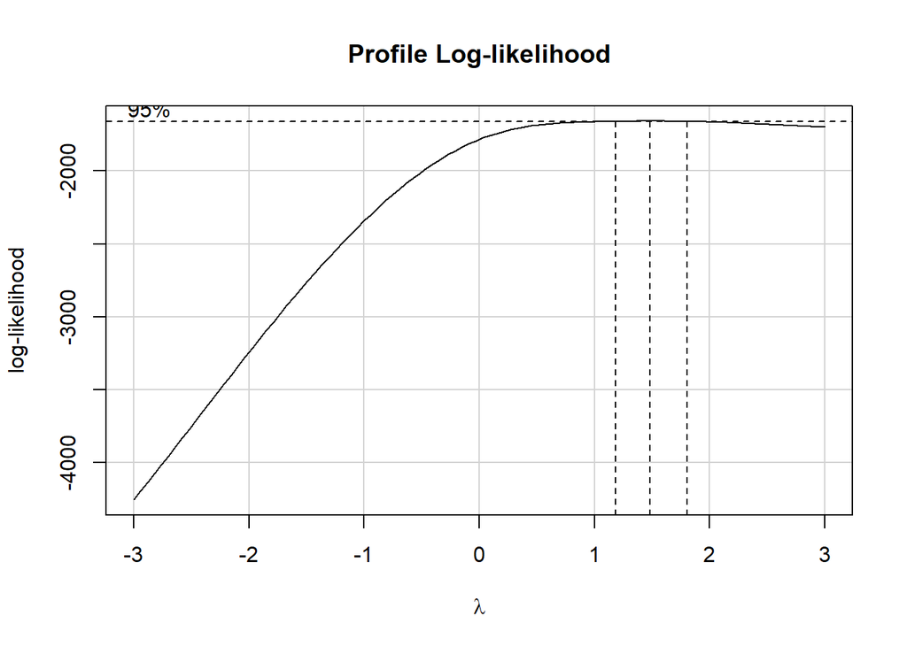

```r
bc_gss.lm.1 <- boxCox(gss.lm.1a, seq(-3, 3), plotit = TRUE)
```

```r
lambda1 <- bc_gss.lm.1$x[which.max(bc_gss.lm.1$y)]
lambda1
```

```
## [1] 1.484848
```

```r
new_df$TVHOURS_sqrt <- sqrt(new_df$TVHOURS)
newdf.lm.2a <- lm(EDUC ~ PAEDUC + PRTNEDUC + TVHOURS_sqrt + RINCMDOL, data = new_df)
summ(newdf.lm.2a)
```

```
## MODEL INFO:
## Observations: 442
## Dependent Variable: EDUC
## Type: OLS linear regression
##
## MODEL FIT:
## F(4,437) = 102.97, p = 0.00
## R² = 0.49
## Adj. R² = 0.48
##
## Standard errors: OLS
## -------------------------------------------------
##                       Est.   S.E.   t val.      p
## ------------------ ------- ------ -------- ------
## (Intercept)           7.56   0.77     9.79   0.00
## PAEDUC                0.12   0.03     4.75   0.00
## PRTNEDUC              0.44   0.04    10.89   0.00
## TVHOURS_sqrt         -0.81   0.25    -3.27   0.00
## RINCMDOL              0.00   0.00     7.12   0.00
## -------------------------------------------------
```

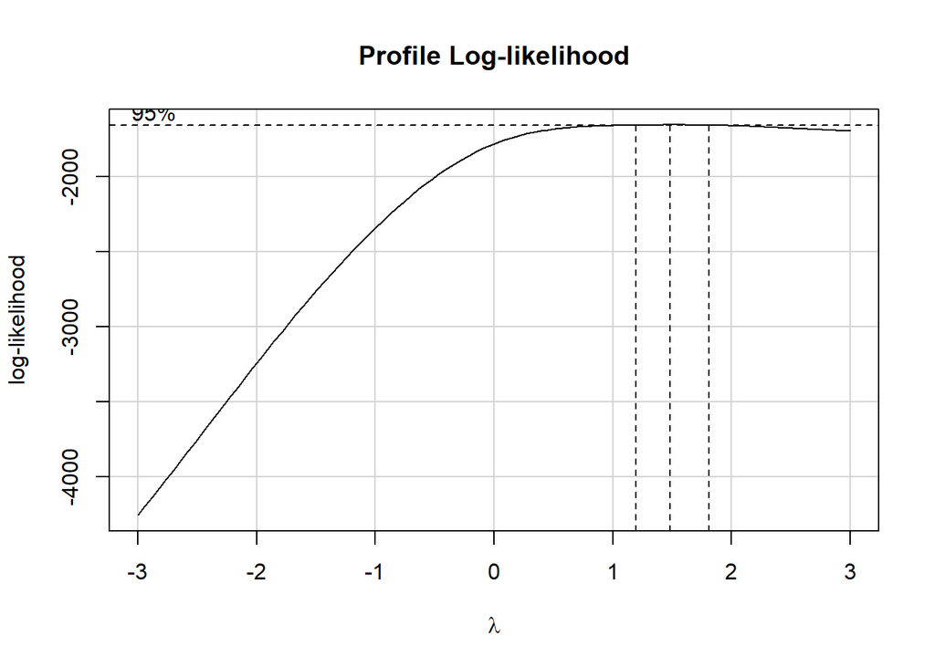

```r
bc_newdf.lm.2 <- boxCox(newdf.lm.2a, seq(-3, 3), plotit = TRUE)
```

```r
lambda2 <- bc_newdf.lm.2$x[which.max(bc_newdf.lm.2$y)]
lambda2
```

```
## [1] 1.484848
```

```r
new_df$PRTNEDUC_sqr<- (new_df$PRTNEDUC)^2
newdf.lm.2b <- lm(EDUC ~ PAEDUC + PRTNEDUC_sqr + TVHOURS_sqrt + RINCMDOL, data = new_df)
summ(newdf.lm.2b)
```

```
## MODEL INFO:
## Observations: 442
## Dependent Variable: EDUC
## Type: OLS linear regression
##
## MODEL FIT:
## F(4,437) = 109.69, p = 0.00
## R² = 0.50
## Adj. R² = 0.50
##
## Standard errors: OLS
## -------------------------------------------------
##                       Est.   S.E.   t val.      p
## ------------------ ------- ------ -------- ------
## (Intercept)          10.37   0.61    16.93   0.00
## PAEDUC                0.13   0.03     5.05   0.00
## PRTNEDUC_sqr          0.02   0.00    11.67   0.00
## TVHOURS_sqrt         -0.79   0.24    -3.24   0.00
## RINCMDOL              0.00   0.00     7.19   0.00
## -------------------------------------------------
```

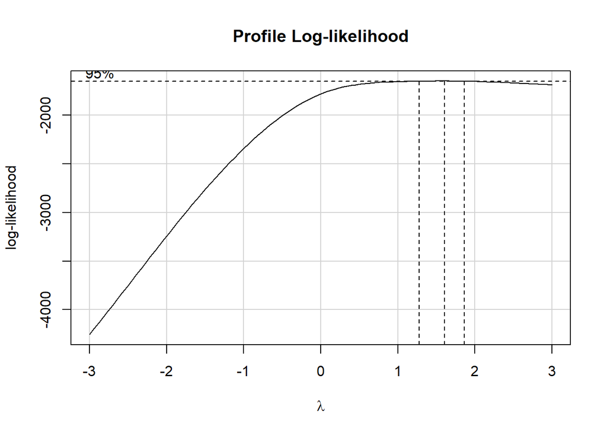

```r
bc_newdf.lm.3 <- boxCox(newdf.lm.2b, seq(-3, 3), plotit = TRUE)
```

```r
lambda3 <- bc_newdf.lm.3$x[which.max(bc_newdf.lm.3$y)]
lambda3
```

```
## [1] 1.606061
```

```r
new_df$EDUC_sqr<- (new_df$EDUC)^2
newdf.lm.2c <- lm(EDUC_sqr ~ PAEDUC + PRTNEDUC_sqr + TVHOURS_sqrt + RINCMDOL, data = new_df)
summ(newdf.lm.2c)
```

```
## MODEL INFO:
## Observations: 442
## Dependent Variable: EDUC_sqr
## Type: OLS linear regression
##
## MODEL FIT:
## F(4,437) = 115.63, p = 0.00
## R² = 0.51
## Adj. R² = 0.51
##
## Standard errors: OLS
## ---------------------------------------------------
##                        Est.    S.E.   t val.      p
## ------------------ -------- ------- -------- ------
## (Intercept)           96.59   17.86     5.41   0.00
## PAEDUC                 3.40    0.74     4.58   0.00
## PRTNEDUC_sqr           0.48    0.04    12.13   0.00
## TVHOURS_sqrt         -23.25    7.06    -3.29   0.00
## RINCMDOL               0.00    0.00     7.76   0.00
## ---------------------------------------------------
```

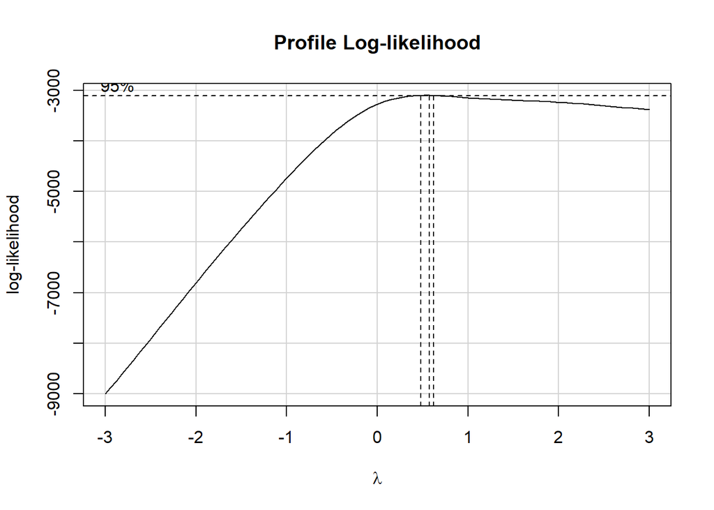

```r
bc_newdf.lm.4 <- boxCox(newdf.lm.2c, seq(-3, 3), plotit = TRUE)
```

```r
lambda4 <- bc_newdf.lm.4$x[which.max(bc_newdf.lm.4$y)]
lambda4
```

```
## [1] 0.5757576
```

```r
new_df$PAEDUC_sqr<- (new_df$PAEDUC)^2
newdf.lm.2d <- lm(EDUC_sqr ~ PAEDUC_sqr + PRTNEDUC_sqr + TVHOURS_sqrt + RINCMDOL, data = new_df)
summ(newdf.lm.2d)
```

```
## MODEL INFO:
## Observations: 442
## Dependent Variable: EDUC_sqr
## Type: OLS linear regression
##
## MODEL FIT:
## F(4,437) = 116.13, p = 0.00
## R² = 0.52
## Adj. R² = 0.51
##
## Standard errors: OLS
## ---------------------------------------------------
##                        Est.    S.E.   t val.      p
## ------------------ -------- ------- -------- ------
## (Intercept)          112.21   17.10     6.56   0.00
## PAEDUC_sqr             0.14    0.03     4.69   0.00
## PRTNEDUC_sqr           0.49    0.04    12.41   0.00
## TVHOURS_sqrt         -22.74    7.06    -3.22   0.00
## RINCMDOL               0.00    0.00     7.73   0.00
## ---------------------------------------------------
```

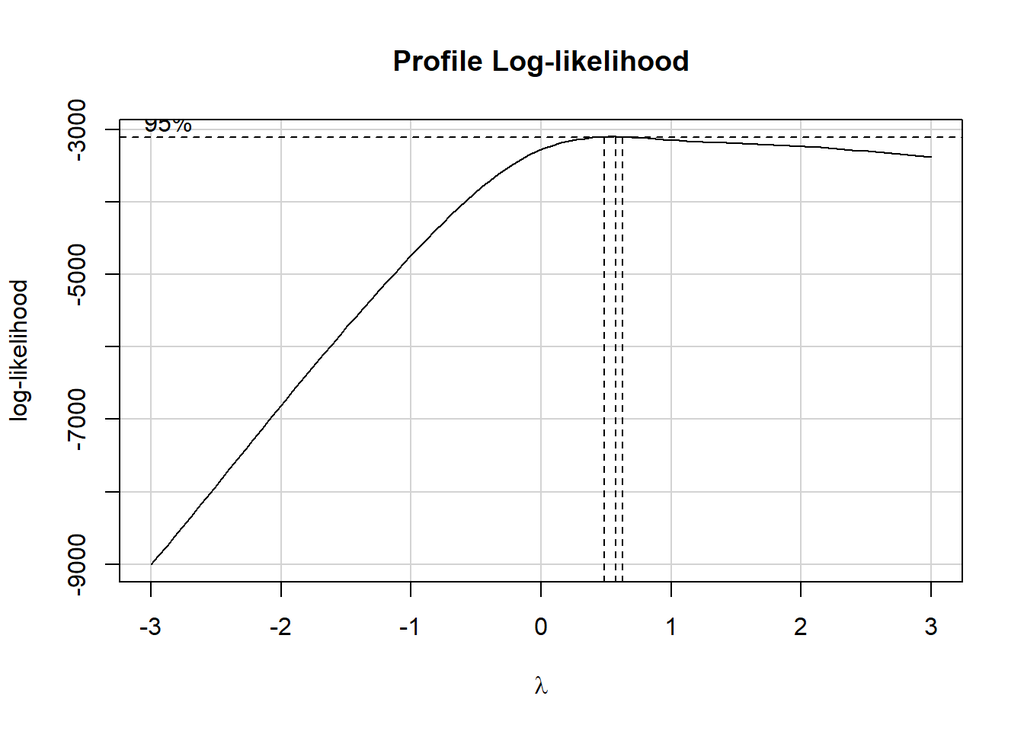

```r
bc_newdf.lm.5 <- boxCox(newdf.lm.2d, seq(-3, 3), plotit = TRUE)
```

```r
lambda5 <- bc_newdf.lm.5$x[which.max(bc_newdf.lm.5$y)]
lambda5
```

```
## [1] 0.5757576
```

7.5. Re-run the diagnostic techniques used above to re-check assumptions and report on whether or not the data transformation(s) made fixed the previous assumption violations.

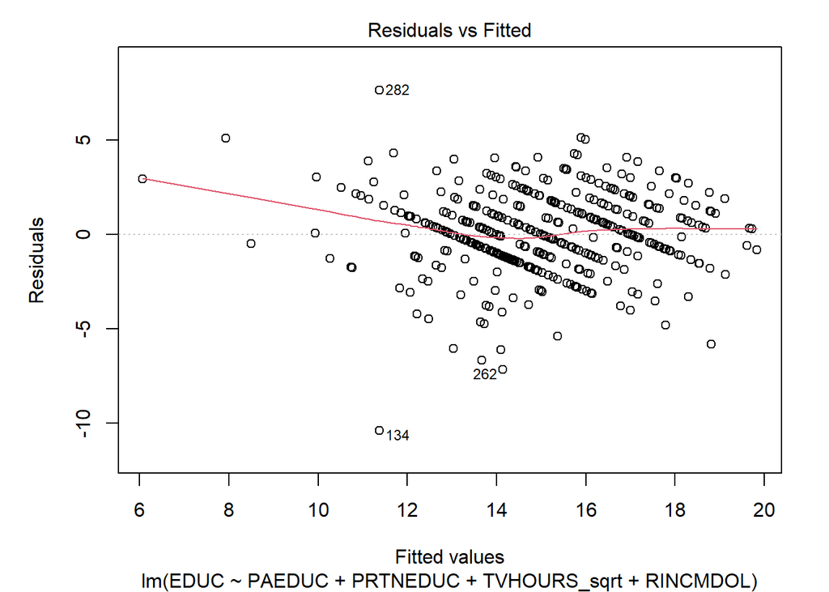

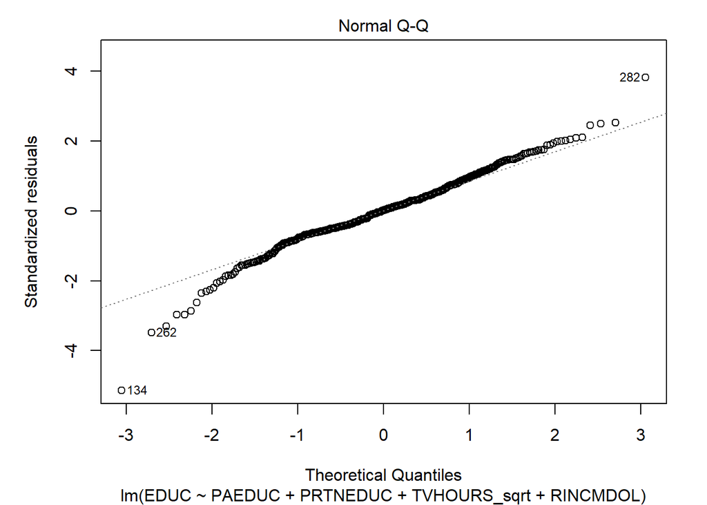

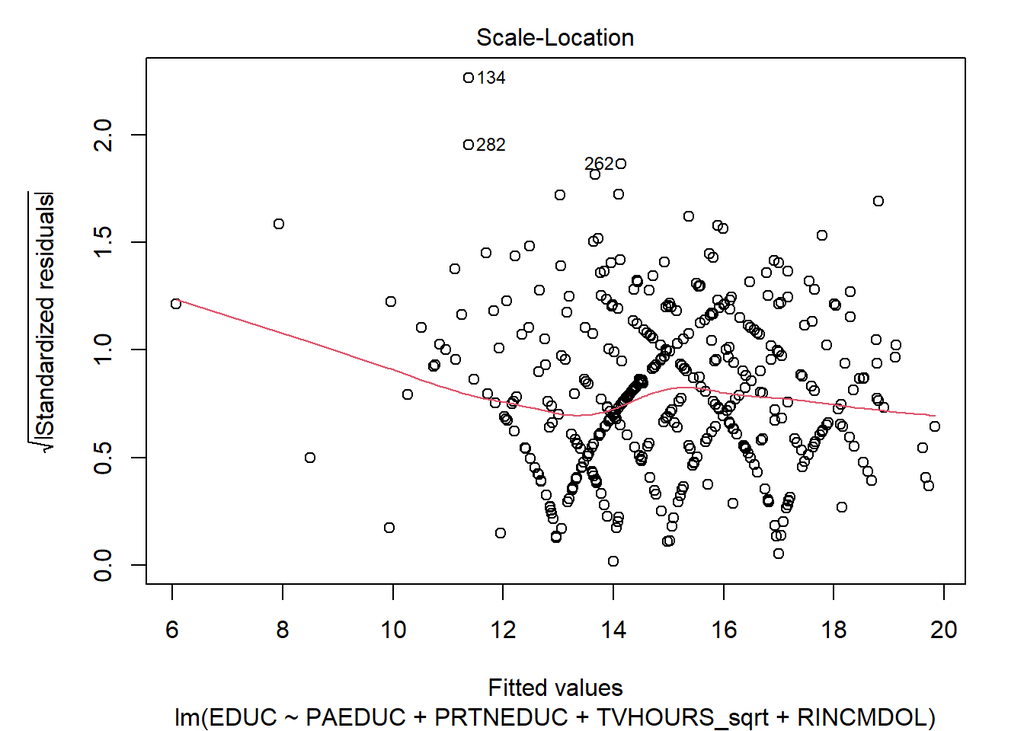

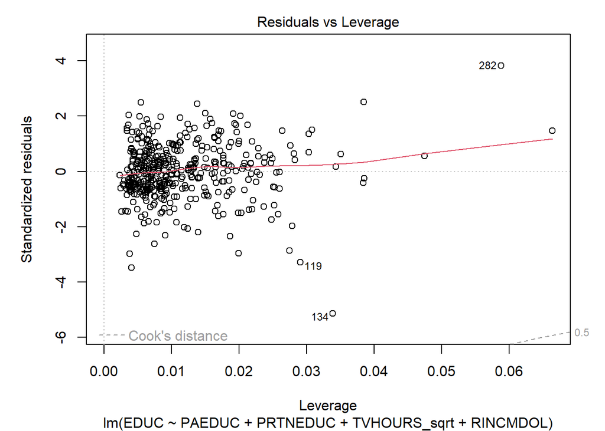

```r
par(mfrow = c(1, 1))
par(mar = c(5, 5, 2, 2))
options(repr.plot.width = 6, repr.plot.height = 4)
plot(newdf.lm.2a)
```

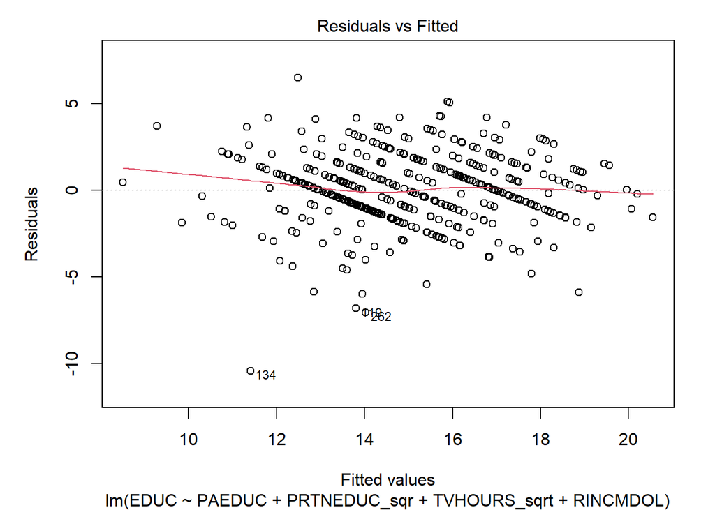

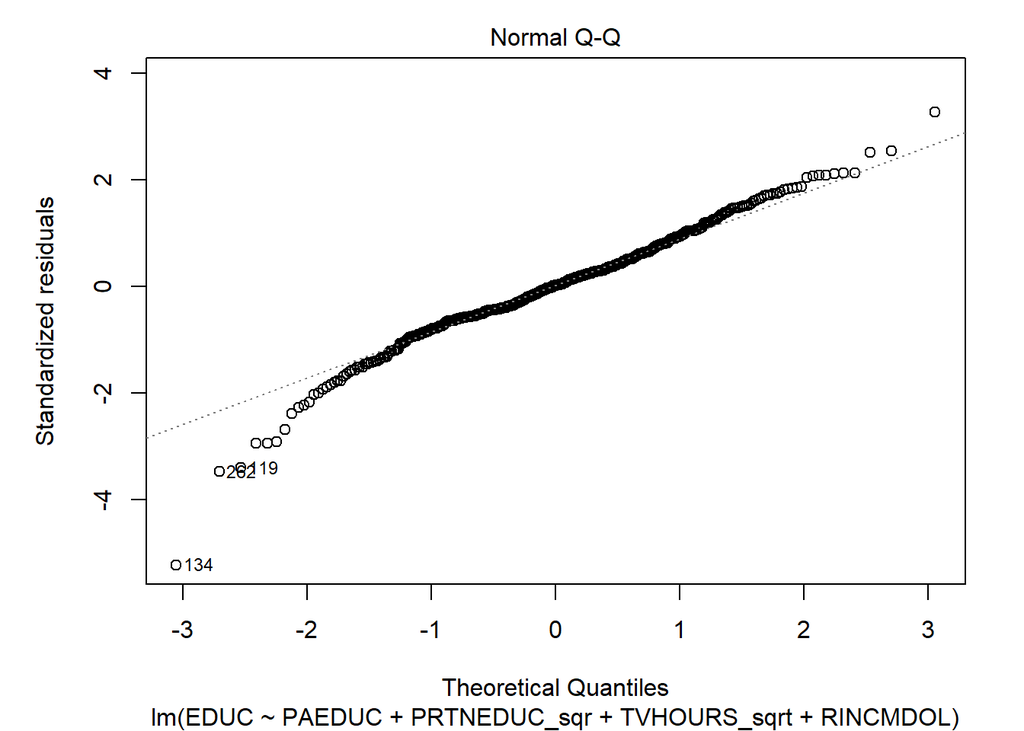

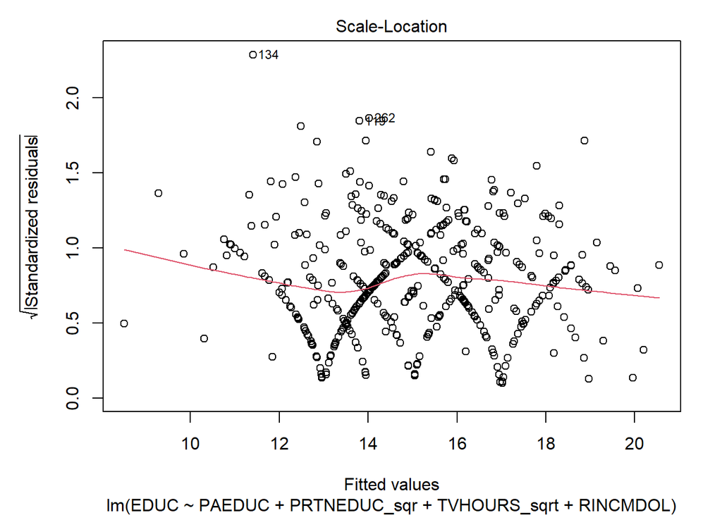

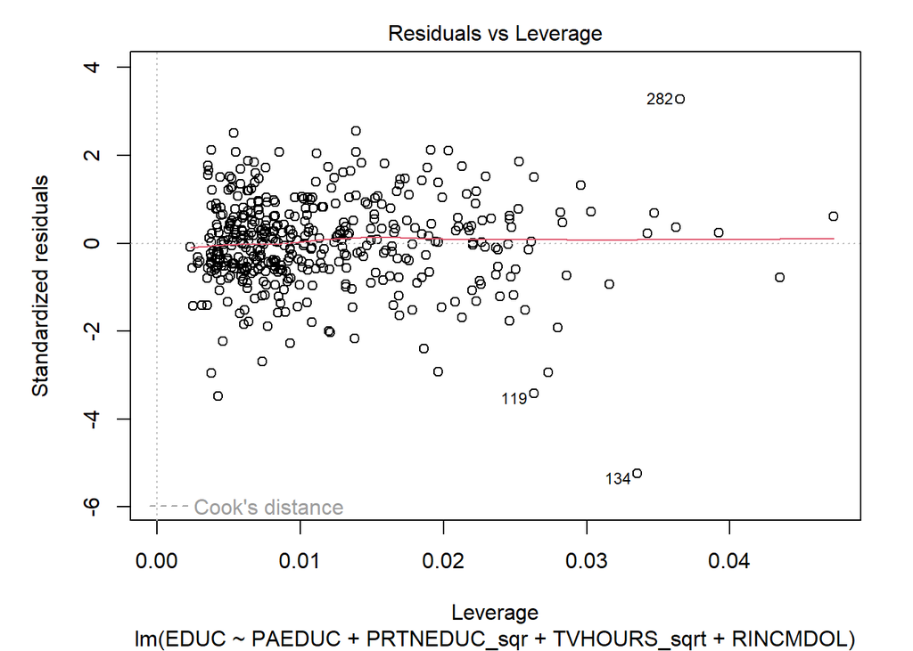

```r
par(mfrow = c(1, 1))
par(mar = c(5, 5, 2, 2))
options(repr.plot.width = 6, repr.plot.height = 4)
plot(newdf.lm.2b)
```

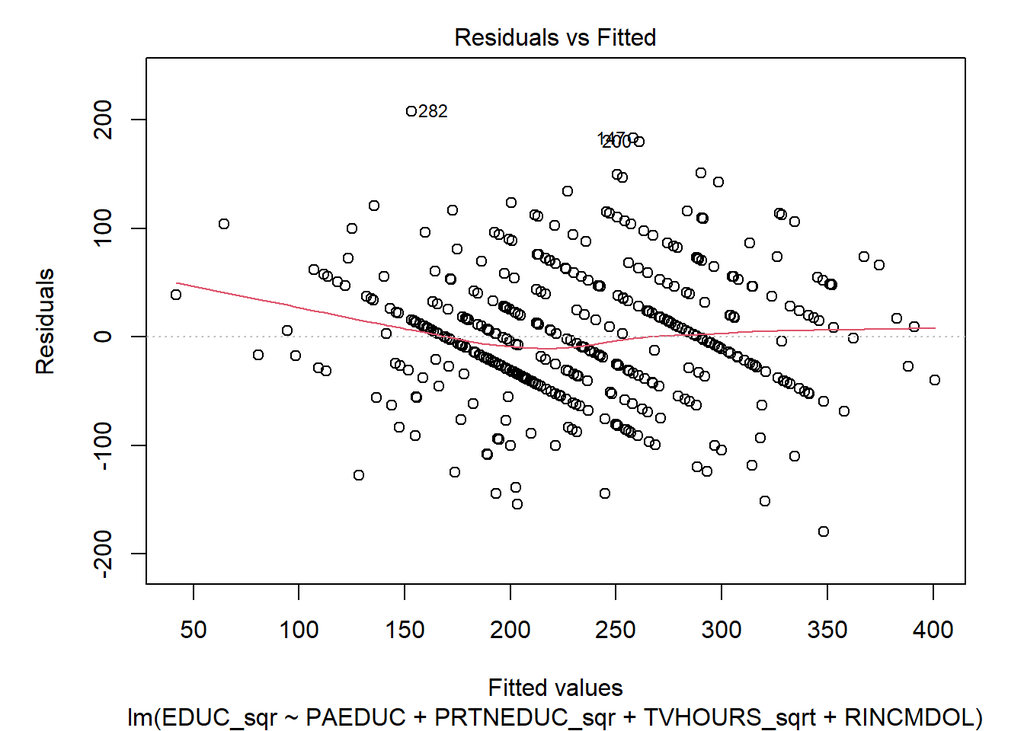

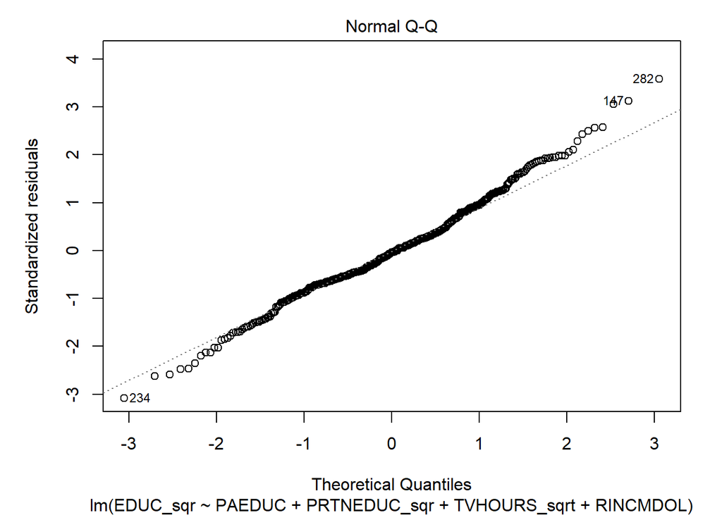

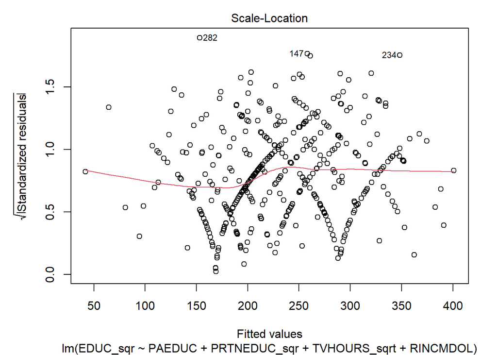

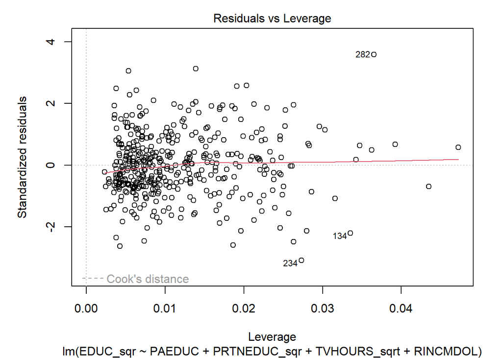

```r
par(mfrow = c(1, 1))
par(mar = c(5, 5, 2, 2))
options(repr.plot.width = 6, repr.plot.height = 4)
plot(newdf.lm.2c)
```

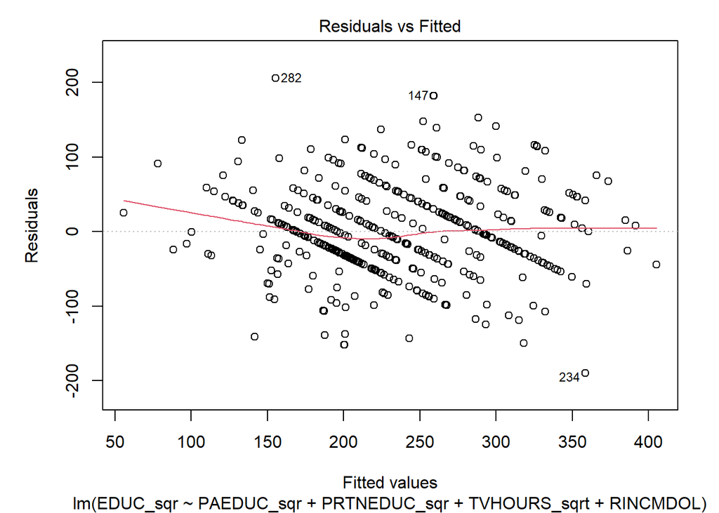

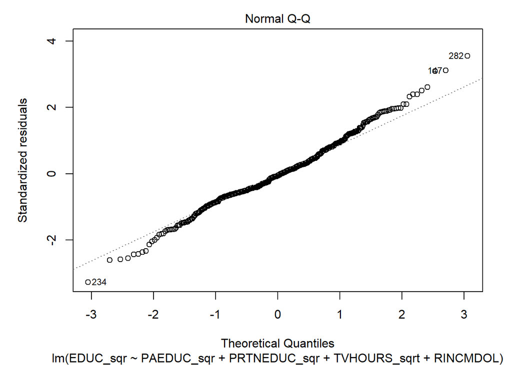

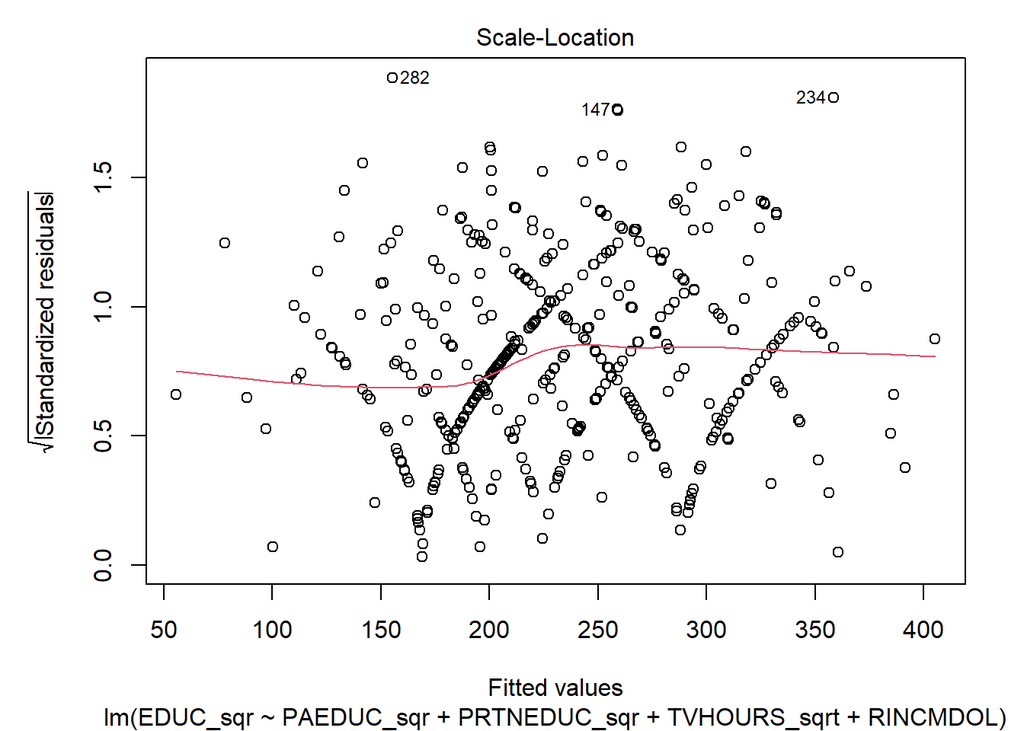

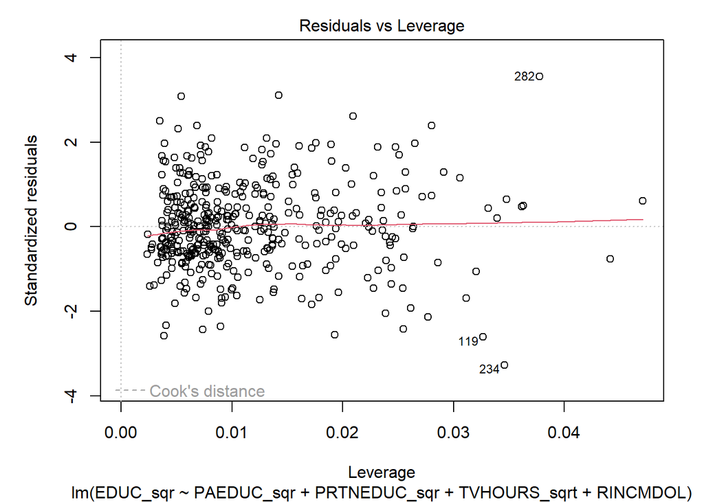

```r
par(mfrow = c(1, 1))
par(mar = c(5, 5, 2, 2))
options(repr.plot.width = 6, repr.plot.height = 4)
plot(newdf.lm.2d)
```

```r
new_df$predicted_2d <- fitted(newdf.lm.2d)
new_df$residuals_2d <- residuals(newdf.lm.2d)
new_df$rstudent_2d <- rstudent(newdf.lm.2d)
new_df$rstandard_2d <- rstandard(newdf.lm.2d)


#Independence
durbinWatsonTest(newdf.lm.2d)
```

```
##  lag Autocorrelation D-W Statistic p-value
##    1      0.02587505      1.947835   0.532
##  Alternative hypothesis: rho != 0
```